# Selecting co-solvents for SFE using Hansen Solubility

## Introduction

This vignette introduces the automated co-solvent selection and ranking workflow for Supercritical Fluid Extraction (SFE) processes, under the assumption that the reader is familiar with the technology. The choice of co-solvent composition and volume fraction (relative to CO<sub>2</sub> flow), or indeed the choice of whether to use a co-solvent at all, is complicated by the different solubility of a target compound(s) contained in the extractable raw material, which is governed by its **cohesive energy density**, itself dependent on **the cohesive energy** and **molar volume**. The [Hansen Solubility Theory](https://www.hansen-solubility.com/HSP-science/basics.php) neatly defines the cohesive energy density of any given molecule (be it solute or solvent) as a set of solubility parameters (**HSP**s) describing the Dispersion, Polarity, and Hydrogen Bonding. These may be derived either experimentally via solubility trials or theoretically using [Group Contribution Methods](https://www.doi.org/10.1016/j.ejpb.2013.04.006) based on automated detection of functional groups from [SMILES](https://www.daylight.com/meetings/summerschool98/course/dave/smiles-intro.html) strings, [SMARTS](https://www.daylight.com/meetings/summerschool01/course/basics/smarts.html) notation, and other molecular descriptors.

The [official website](https://www.hansen-solubility.com) of the Hansen Solubility Theory and the accompanying [book](https://www.doi.org/10.1201/9781420006834) provide comprehensive information about the theory, while several real world applications (e.g. [here](https://www.doi.org/10.1016/j.ces.2018.06.017), [here](https://www.doi.org/10.3303/CET197502), and [here](https://doi.org/10.1016/j.jfoodeng.2025.112538)) give specific examples of its usefulness. In lieu of reciting their content herein, the reader is directed to familiarize themselves with both SFE and Hansen Solubility using the available sources. This vignette instead aims to provide a worked example(s) showcasing the capability of `supeRcrit` and the workflow encompassed by the `sfe_mod` function to help:

1. Retrieve molecular descriptors of a target compound.
2. Estimation of boiling point, critical parameters, and HSPs.
3. Estimate performance of various co-solvent for said compound.
4. Comparison of a single co-solvent for multiple targets, pressures, temperatures, and/or volume fractions.

## Worked examples

### Retrieval of molecular descriptors

The workflow begins by retrieving molecular descriptors for a target compound. Although the `sfe_mod` function carries this out automatically, it is also useful as a separate function termed `mol_find`. All the user is required to provide is a target [CAS](https://www.cas.org/cas-data/cas-registry) number and preferred name of a molecule. Let’s use beta-carotene as an example:

```r
mol <- mol_find(c("Beta-carotene", "7235-40-7"))

#View results except InChI
mol$IDs[!names(mol$IDs) %in% "InChI"]
```

```
#>                                                                        Name
#>                                                             "Beta-carotene"
#>                                                                         CAS
#>                                                                 "7235-40-7"
#>                                                                      SMILES
#> "CC1=C(C(CCC1)(C)C)C=CC(=CC=CC(=CC=CC=C(C)C=CC=C(C)C=CC2=C(CCCC2(C)C)C)C)C"
#>                                                                    InChIKey
#>                                               "OENHQHLEOONYIE-UHFFFAOYSA-N"
#>                                                                  Atom_Count
#>                                                                        "96"
#>                                                                     H_Count
#>                                                                        "56"
#>                                                                          MW
#>                                                             "536.438201792"
#>                                                                          MF
#>                                                                    "C40H56"
#>                                                                 Aromaticity
#>                                                                     "FALSE"
```

We can additionally provide the SMILES string explicitly if required:

```r
#The SMILES string may also be specified:
mol_data <- c("7235-40-7", "Beta-carotene", "CC1=C(C(CCC1)(C)C)C=CC(=CC=CC(=CC=CC=C(C)C=CC=C(C)C=CC2=C(CCCC2(C)C)C)C)C")
mol <- mol_find(mol_data)
```

Although the function automatically determines the nature of input vector elements based on their formatting, the user may also explicitly name them as follows (**code not run**):

```r
mol_find(c(CAS = "7235-40-7",
           Name = "Beta-carotene",
           SMILES = "CC1=C(C(CCC1)(C)C)C=CC(=CC=CC(=CC=CC=C(C)C=CC=C(C)C=CC2=C(CCCC2(C)C)C)C)C"))
```

### Estimation of boiling point, critical parameters, and HSPs

The determination of co-solvent performance as target compound miscibility enhancers in supercritical CO<sub>2</sub> requires estimation of their critical temperature and HSP values. Similarly to `mol_find`, the `sfe_mod` function handles this automatically, but a separate routine `est_gcm` provides this useful functionality as well. The function implements the [Joback-Reid](https://doi.org/10.1080/00986448708960487), [Stein and Brown](https://doi.org/10.1021/ci00019a016), [Nannoolal](https://doi.org/10.1016/j.fluid.2006.11.014), [Stefanis and Panayiotou](https://doi.org/10.1016/j.ijpharm.2012.01.001), and [Hukkerikar](https://doi.org/10.1016/j.fluid.2012.02.010) group contribution methods (GCMs) for estimating critical parameters and Hansen Solubility. Additionally, van der waals volume (in L mole<sup>-1</sup>) can be estimated by the methods of Slonimskii, [Bondi](https://doi.org/10.1021/j100785a001), and [Zhao](https://doi.org/10.1021/jo034808o). Once again using beta-carotene as an example:

```r
gcm_res <- est_gcm(solute = mol_data,
                   tb = "SB_corr", #The corrected Stein and Brown method for boiling point estimation
                   crit = "JR", #Joback-Reid method for boiling point estimation
                   hsp = "SP12", #Stefanis and Panayiotou method for HSP estimation
                   vdw = "ZHAO", #Zhao method for van der Waals volume (VDW) estimation
                   silent = TRUE)
#Show estimated parameters
gcm_res[["pares"]][1:4]
```

```
#> $Critical
#>          Tb          Tc          Pc          Vc
#>  856.307266 1048.530094    6.072617 1933.500000
#>
#> $HSP
#>       dD       dP      dHB   dP_low  dHB_low
#> 12.41942  0.00000  0.00000  2.31210  6.13510
#>
#> $VDW
#>          VDW
#> 0.0007219425
#>
#> $Methods
#>        Tb  Critical       HSP       VDW
#> "SB_corr"      "JR"    "SP12"    "ZHAO"
```

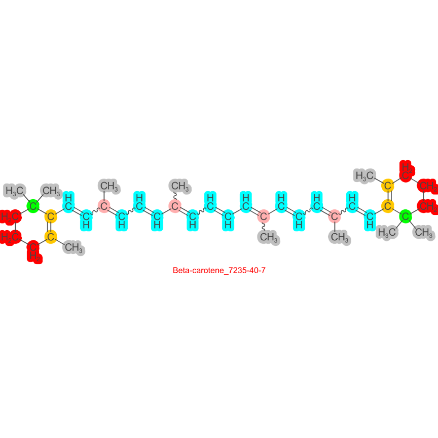

```r
#Visualise the fragmentation patterns (example given is for Stein and Brown boiling point estimation method)
grid::grid.raster(gcm_res[["visres"]][[1]], width = 1, height = 1, vp = grid::viewport(xscale = c(0,1), yscale = c(0,1)))
```

All GCM approaches require fragmentation of a molecular structure into discrete representative groups where overlapping atoms between identified groups are either permitted or disallowed depending on the selected method. Manual group fragmentation may be time-consuming and in this package various automatic fragmentation approaches are instead employed, most of these were inspired by the work of [Peter Ertl](https://doi.org/10.1186/s13321-017-0225-z) and [Simon Müller](https://doi.org/10.1186/s13321-019-0382-3). The `simplicity` argument (rather fittingly) determines the level of simplicity of the automatic fragmentation algorithm. Besides the default setting, `"auto"`, the three possible values are:

- `"simple"`: Group overlap is allowed.
- `"normal"`: Group overlap is not allowed, with the first valid fragmentation pattern accepted.
- `"complex"`: Group overlap is not allowed and every possible fragmentation pattern is computed before final selection.

Note that the above are overridden for second- and third-order groups, where the parameters of fragmentation are the same as those originally published (for more detail, the reader is referred to the primary literature linked throughout this document). For some molecules, the `"complex"` approach may take hours to settle on a single fragmentation pattern out of possible thousands, but for others (like 2-methylphenanthrene exemplified below) the routine is surprisingly fast. Nevertheless, the remaining two approaches are significantly more practical, but still differ in execution time and performance:

```r
#Define a new molecule which should contain groups of multiple orders
mol_data <- c("2531-84-2", "2-methylphenanthrene")
mol <- mol_find(mol_data)

#Compare the fragmentation time using the Hukkerikar approach for critical parameter estimation
taken <- c()
start_1 <- Sys.time()
res_simple <- est_gcm(solute = mol_data, crit = "HKR_STW", simplicity = "simple", silent = TRUE)
end_1 <- Sys.time()
taken["simple"] <- round(end_1 - start_1, 2)

#For the 'normal' simplicity level
start_2 <- Sys.time()
res_normal <- est_gcm(solute = mol_data, crit = "HKR_STW", simplicity = "normal", silent = TRUE)
end_2 <- Sys.time()
taken["normal"] <- round(end_2 - start_2, 2)

#For the 'complex' simplicity level
start_3 <- Sys.time()
res_complex <- est_gcm(solute = mol_data, crit = "HKR_STW", simplicity = "complex", silent = TRUE)
```

[output not shown]

```r
end_3 <- Sys.time()
taken["complex"] <- round(end_3 - start_3, 2)
taken
```

```
#>  simple  normal complex
#>    3.41    3.62    7.69
```

```r
reslist <- list(res_simple, res_normal, res_complex)

#Retrieve and show estimated critical temperatures
setNames(sapply(reslist, function(x) x[["pares"]][["Critical"]][["Tc"]]), c("simple_Tc", "normal_Tc", "complex_Tc"))
```

```
#>  simple_Tc  normal_Tc complex_Tc
#>   1041.414    878.017    878.017
```

```r
#Show the number of UNIQUE identified groups
setNames(sapply(reslist, function(x) nrow(x[["pares"]][["Contribs"]][["Critical"]])), c("simple_groups", "normal_groups", "complex_groups"))
```

```
#>  simple_groups  normal_groups complex_groups
#>             19              5              5
```

We see that the `simple` method likely vastly overestimates the critical temperature due to the overabundance of identified groups, while there is no need for the `complex` approach in this case since it results in the same estimation as the more time-efficient `normal` approach.

Finally, some GCMs examine multiple levels of functional groups, otherwise known as **group orders**, to refine initial estimates from the so-called first-order groups. This can also alter estimates as exemplified below using the `gorder` argument:

```r
#By default, consider all groups (first- and second-order in this case)
res1 <- est_gcm(solute = mol_data, hsp = "SP12", gorder = 0, silent = TRUE)

#Consider only first-order groups
res2 <- est_gcm(solute = mol_data, hsp = "SP12", gorder = 1, silent = TRUE)

res1[["pares"]][["HSP"]]
```

```
#>       dD       dP      dHB   dP_low
#> 20.72574  0.42750  4.98000  1.36840
```

```r
res2[["pares"]][["HSP"]]
```

```
#>       dD       dP      dHB  dHB_low
#> 21.26372  4.86270  2.73960  1.60640
```

Naturally, given the variety of underlying models, different GCMs result in slightly (and sometimes significantly) different parameter estimates. These differences may be quickly displayed via the `compare_gcm` function as below:

```r
cgcm <- compare_gcm(mol_data, simplicity = "simple")
```

[output not shown]

```r
knitr::kable(cgcm, format = "html", digits = 2) |>  kableExtra::kable_styling(full_width = T)
```

| parameter | method | simplicity | order | Tb | Tb_corr | Tc | Pc | Vc | dD | dP | dHB | dP_low | VDW |
| --- | --- | --- | --- | --- | --- | --- | --- | --- | --- | --- | --- | --- | --- |
| tb | JR | simple | 1 | 617.40 | NA | NA | NA | NA | NA | NA | NA | NA | NA |
| tb | JR_corr | simple | 1 | 617.40 | 573.18 | NA | NA | NA | NA | NA | NA | NA | NA |
| tb | SB | simple | 1 | 630.75 | NA | NA | NA | NA | NA | NA | NA | NA | NA |
| tb | SB_corr | simple | 1 | 630.75 | 581.14 | NA | NA | NA | NA | NA | NA | NA | NA |
| tb | NL04 | simple | 2 | 616.70 | NA | NA | NA | NA | NA | NA | NA | NA | NA |
| tb | HKR_STW | simple | 3 | 618.69 | NA | NA | NA | NA | NA | NA | NA | NA | NA |
| tb | HKR_SIM | simple | 3 | 598.58 | NA | NA | NA | NA | NA | NA | NA | NA | NA |
| crit | JR | simple | 1 | NA | NA | 815.73 | 28.69 | 611.50 | NA | NA | NA | NA | NA |
| crit | NL07 | simple | 2 | NA | NA | 828.74 | 30.29 | 625.58 | NA | NA | NA | NA | NA |
| crit | NL07_robust | simple | 2 | NA | NA | 828.74 | 30.29 | 625.58 | NA | NA | NA | NA | NA |
| crit | HKR_STW | simple | 3 | NA | NA | 1041.41 | 51.29 | 496.34 | NA | NA | NA | NA | NA |
| crit | HKR_SIM | simple | 3 | NA | NA | 1041.42 | 29.91 | 691.58 | NA | NA | NA | NA | NA |
| hsp | SP08 | simple | 2 | NA | NA | NA | NA | NA | 20.79 | 0.59 | 5.04 | 1.23 | NA |
| hsp | SP12 | simple | 2 | NA | NA | NA | NA | NA | 20.73 | 0.43 | 4.98 | 1.37 | NA |
| hsp | HKR_STW | simple | 3 | NA | NA | NA | NA | NA | 10.25 | 7.62 | 0.00 | NA | NA |
| hsp | HKR_SIM | simple | 3 | NA | NA | NA | NA | NA | 11.79 | 52.33 | 0.00 | NA | NA |
| vdw | BND | simple | 1 | NA | NA | NA | NA | NA | NA | NA | NA | NA | 0 |
| vdw | SLON | simple | 1 | NA | NA | NA | NA | NA | NA | NA | NA | NA | 0 |
| vdw | ZHAO | simple | 1 | NA | NA | NA | NA | NA | NA | NA | NA | NA | 0 |

While the values are often consistent between methods, it is recommended to survey the results are much as possible for each individual target compound before settling on a particular set of GCMs, since the accuracy of predicted parameters significantly impacts subsequent co-solvent performance estimation.

### Estimation of co-solvent performance for one compound

The `sfe_mod` routine uses the [Hansen Solubility Theory](https://www.hansen-solubility.com/HSP-science/basics.php) to estimate the **relative** improvement in the miscibility of a target compound (the so-called *% Miscibility Enhancement*) in a **binary CO2 : co-solvent system** of a specified composition. This allows one to determine whether addition of a specific co-solvent(s) at various concentrations improves the solubility of a target compound relative to pure supercritical CO<sub>2</sub>, and how said improvements compare between different solvents.

The solvent systems are finally ranked at each possible set of conditions within the user-specified range, and the system providing the largest miscibility enhancement is chosen as the “best”.

Let us determine the miscibility enhancement for xanthohumol, a prenylflavonoid commonly found in hops and poorly soluble in supercritical CO<sub>2</sub>, using various co-solvents at a volume fraction of 0.1.

```r
xantho <- c(hspex[hspex[,"Name"] == "Xanthohumol",c("SMILES", "CAS", "Name")])

res <- sfe_mod(solute = xantho,
               tb = "SB_corr",
               pres = seq_last(80, 400, 60),
               temp = seq_last(32, 70, 9),
               vfrac = 0.1,
               crit = "NL07_robust",
               hsp = "SP12",
               simplicity = "normal")
```

```
#>
#> Retrieving compound data...
#> Calculating/retrieving boiling point ...
#> Calculating/retrieving critical temperature and other parameters ...
#> Calculating/retrieving Hansen Solubility Parameters (HSP) ...
#> Rounding SFE temperature and pressure constraints to whole numbers...
#> Calculating SFE miscibility enhancement using a 0.1 volume fraction of the following modifiers: 'Acetone', 'Benzene', 'Cyclohexane', 'DiethylEther', 'Ethanol', 'Heptane', 'Hexane', 'Methanol', 'MethylOleate', 'Toluene', 'PXylene', 'OXylene', 'Water'.
#> Calculating temperature influence of HSP values of solute...
#> Processing molar volumes...
#> Calculating the temperature and pressure influence on HSP of solvent(s)...
#> Calculating Ra distances and Miscibility Enhancement (%)...
#> DONE!
```

```r
#Check the list of evaluated solvents
res[["sfe"]][["Modifiers"]]
```

```
#>  [1] "Acetone"      "Benzene"      "Cyclohexane"  "DiethylEther" "Ethanol"      "Heptane"
#>  [7] "Hexane"       "Methanol"     "MethylOleate" "Toluene"      "PXylene"      "OXylene"
#> [13] "Water"
```

```r
#Display the best solvent at each set of conditions (80-400 bar and 32-70 C)
res[["sfe"]][["Best_Modifier"]]
```

```
#>     32    41    50    59    68    70
#> 80  "H2O" "H2O" "H2O" "H2O" "H2O" "H2O"
#> 140 "H2O" "H2O" "H2O" "H2O" "H2O" "H2O"
#> 200 "H2O" "H2O" "H2O" "H2O" "H2O" "H2O"
#> 260 "H2O" "H2O" "H2O" "H2O" "H2O" "H2O"
#> 320 "H2O" "H2O" "H2O" "H2O" "H2O" "H2O"
#> 380 "H2O" "H2O" "H2O" "H2O" "H2O" "H2O"
#> 400 "H2O" "H2O" "H2O" "H2O" "H2O" "H2O"
```

```r
#Display the overall ranking (based on the proportion of conditions at which a particular solvent provides the highest enhancement)
res[["sfe"]][["Modifier_Ranking"]]
```

```
#>
#> H2O
#> 100
```

It appears that using water as a co-solvent provides by far the best enhancement of miscibility throughout the tested temperature and pressure range. However, let us compare the miscibility enhancement obtained with other solvents to see whether any show similar performance.

```r
solv_list <- c("Hexane", "Toluene", "Methanol", "Ethanol", "Water")
reslist <- list()
for(i in solv_list){
  reslist[[paste0("CO2 with ",i)]] <- c(i, round(range(res[["sfe"]][["Miscib_Enhancement"]][[paste0("CO2 with ", i)]]),2))
}
setNames(Reduce("rbind.data.frame", reslist), c("Co-solvent", "Min", "Max"))
```

```
#>   Co-solvent   Min   Max
#> 1     Hexane -1.48  5.64
#> 2    Toluene  0.39  7.66
#> 3   Methanol  7.38  8.34
#> 4    Ethanol  6.72  8.61
#> 5      Water 10.96 15.56
```

The table of minimum and maximum miscibility enhancements reveals that while water is the best modifier, both ethanol and methanol are also likely to benefit the extraction of xanthohumol. What if we were to use a mixture of ethanol and water (e.g. 1:1)? Let us try.

```r
res <- sfe_mod(solute = xantho,
               modif = list(c("Ethanol", "Water"), "Water"),
               modfracs = list(50),
               tb = "SB_corr",
               crit = "NL07_robust",
               hsp = "SP12",
               pres = seq_last(80, 400, 60),
               temp = seq_last(32, 70, 9),
               vfrac = 0.1,
               simplicity = "normal",
               silent = TRUE)

res[["sfe"]][["Miscib_Enhancement"]]
```

```
#> $`CO2 with Ethanol:Water (50:50)`
#>           32        41        50        59        68        70
#> 80  10.17202  9.745872  9.761944  9.800093  9.845462  9.855458
#> 140 10.60160 10.561754 10.497678 10.418442 10.359478 10.353413
#> 200 10.79730 10.808233 10.813504 10.811461 10.805968 10.804443
#> 260 10.93924 10.974832 11.009973 11.043097 11.074803 11.081270
#> 320 11.05205 11.104413 11.157555 11.212127 11.266922 11.279496
#> 380 11.14571 11.209401 11.276329 11.345188 11.416932 11.433645
#> 400 11.17335 11.240199 11.310915 11.383639 11.460239 11.477625
#>
#> $`CO2 with Water`
#>           32       41       50       59       68       70
#> 80  12.80944 11.09236 10.97970 10.95589 10.96160 10.96509
#> 140 14.08475 13.76147 13.35213 12.88578 12.49273 12.42795
#> 200 14.60474 14.43777 14.24461 14.02558 13.79246 13.73997
#> 260 14.96933 14.87410 14.76806 14.64932 14.52016 14.49050
#> 320 15.25355 15.20555 15.15092 15.09026 15.02482 15.01066
#> 380 15.48838 15.47272 15.45517 15.43412 15.41344 15.40940
#> 400 15.55781 15.55068 15.54412 15.53414 15.52602 15.52377
```

It appears that the performance of 1:1 ethanol:water as a co-solvent is somewhere between that of pure ethanol and water, as expected.

The output of `sfe_mod` may be exported as a .CSV file using the `hsp_export` function (**code not run**):

```r
hsp_export(res,
           expath = "C:/HSP") #Hypothetical export path as a string
```

### Comparison of co-solvents for various targets, temperatures, and/or pressures

Sometimes it is beneficial to survey co-solvent performance for different target compounds at various ranges of process pressure, temperature, and co-solvent volume fraction relative to that of CO<sub>2</sub>. The function `miscomp` simplifies this with visual representations of miscibility enhancement as shown below.

```r
#fig.height = 15, fig.width = 7.5
#Define two analytes to compare
mol1 <- c(hspex[1,c("SMILES", "CAS", "Name")]) #Beta-carotene
mol2 <- c(hspex[24,c("SMILES", "CAS", "Name")]) #Xanthohumol

#Compare miscibility enhancement
gcm_comp <- miscomp(sols = list(mol1, mol2), simplicity = "normal") #Uses default volume fraction, pressure range, temperature etc.
```

```
#>
#> Working on compound 1 of 2 ...
#> Calculating HSPs and other parameters...
#> Calculating miscibility enhancement...
#> Compiling data...
#> Working on compound 2 of 2 ...
#> Calculating HSPs and other parameters...
#> Calculating miscibility enhancement...
#> Compiling data...
```

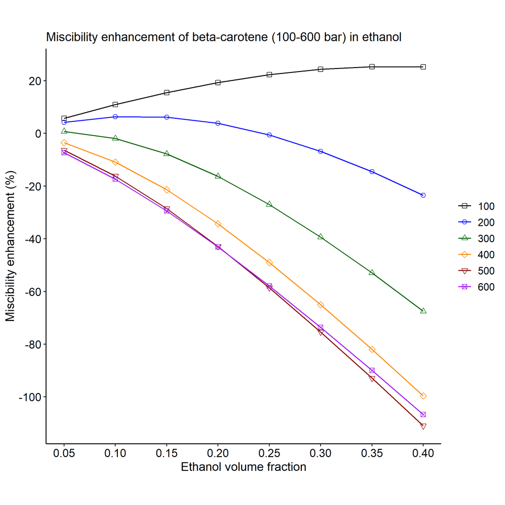

```r
#Display plots for both compounds
gcm_comp[["plots"]][["Beta-carotene"]]
```

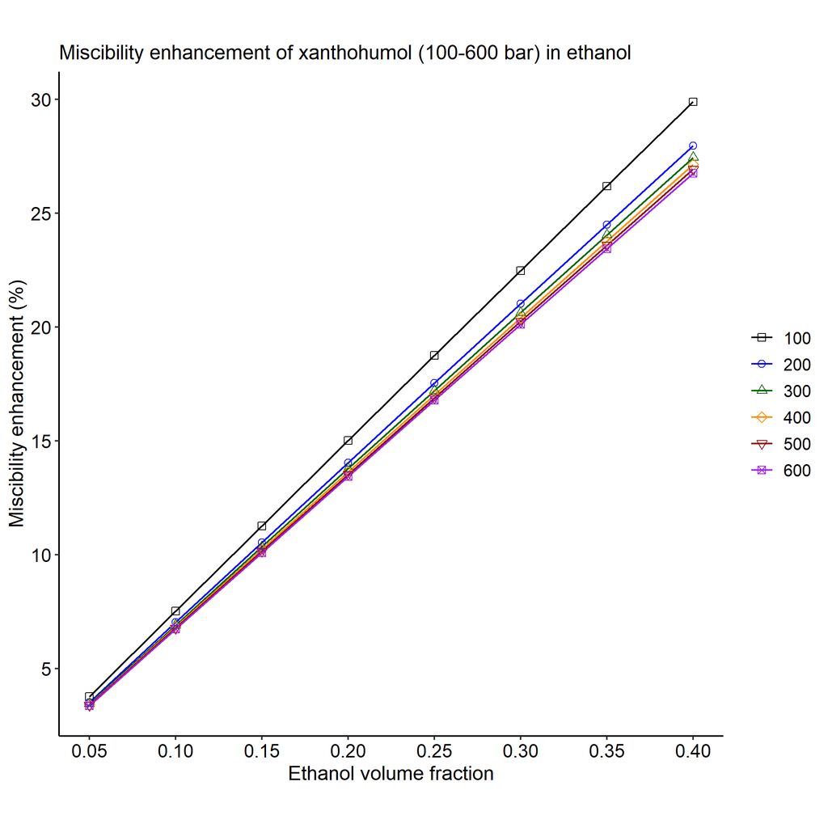

```r
gcm_comp[["plots"]][["Xanthohumol"]]
```